# **Comparative analysis of gene expression profiles between Alzheimer’s-related genes and healthy controls using Myeloid.**

## **DESeq2 Framework Using PyDESeq2**

Design: 3 **Control** vs 3 Alzheimer Diseased (**AD**)

### **What is RNA-Seq?**

RNA sequencing (RNA-Seq) is a high-throughput method used to measure gene expression by sequencing cDNA derived from RNA molecules.

The general workflow is:

1. RNA extraction
2. Library preparation
3. Sequencing
4. Read alignment (or pseudo-alignment)
5. Counting reads per gene
6. Statistical modeling of counts
7. Identification of differentially expressed genes

In this notebook, we begin at Step 6 — using a gene count matrix.

```python
!pip install pydeseq2
```

```python
import pandas as pd
import numpy as np
import matplotlib.pyplot as plt
import seaborn as sns
from pydeseq2.dds import DeseqDataSet
from pydeseq2.ds import DeseqStats
from sklearn.decomposition import PCA
from sklearn.preprocessing import StandardScaler
plt.style.use('seaborn-v0_8')
```

## **Load Count Matrix**

```python
counts = pd.read_csv('/content/counts_Myeloid.csv', index_col=0)
counts.head()
```

| Geneid | AD_1 | AD_2 | Control_1 | Control_2 | AD_3 | Control_3 |
| --- | --- | --- | --- | --- | --- | --- |
| ENSG00000279928 | 6 | 2 | 2 | 2 | 0 | 0 |
| ENSG00000228037 | 4 | 1 | 5 | 1 | 13 | 14 |
| ENSG00000142611 | 49 | 17 | 14 | 20 | 38 | 3 |
| ENSG00000284616 | 0 | 0 | 3 | 0 | 0 | 0 |
| ENSG00000157911 | 14 | 11 | 16 | 0 | 25 | 6 |

```python
counts.shape
```

```
(62754, 6)
```

## **Create Metadata (3 Control, 3 AD)**

### **Experimental Design**

In this experiment:

- 3 Biological Replicates (Control)
- 3 Biological Replicates (AD)

Why replicates matter: Biological replicates allow us to estimate biological variability. Without replicates, we cannot estimate dispersion properly.

Statistical power in RNA-seq depends heavily on:

- Number of replicates
- Sequencing depth
- Effect size

```python
# Remove the incorrect re-indexing, as 'Geneid' is already the index from csv load.
# counts = counts.set_index(counts.columns[0])

# Keep only numeric columns
# counts = counts.select_dtypes(include=[np.number])

# Confirm
print("Shape:", counts.shape)
print("Columns:", counts.columns.tolist())

# Create metadata based on column names for robustness
sample_names = counts.columns.tolist()
conditions = []
for name in sample_names:
    if 'Control' in name:
        conditions.append('control')
    elif 'AD' in name:
        conditions.append('AD')
    else:
        conditions.append('unknown') # Fallback for unexpected names

metadata = pd.DataFrame(
    {"condition": conditions},
    index=counts.columns
)

metadata
```

```
Shape: (62754, 6)
Columns: ['AD_1', 'AD_2', 'Control_1', 'Control_2', 'AD_3', 'Control_3']
```

|  | condition |
| --- | --- |
| AD_1 | AD |
| AD_2 | AD |
| Control_1 | control |
| Control_2 | control |
| AD_3 | AD |
| Control_3 | control |

```python
counts.head()
```

| Geneid | AD_1 | AD_2 | Control_1 | Control_2 | AD_3 | Control_3 |
| --- | --- | --- | --- | --- | --- | --- |
| ENSG00000279928 | 6 | 2 | 2 | 2 | 0 | 0 |
| ENSG00000228037 | 4 | 1 | 5 | 1 | 13 | 14 |
| ENSG00000142611 | 49 | 17 | 14 | 20 | 38 | 3 |
| ENSG00000284616 | 0 | 0 | 3 | 0 | 0 | 0 |
| ENSG00000157911 | 14 | 11 | 16 | 0 | 25 | 6 |

### **Sanity Checks: Data Type**

```python
print("Counts DataFrame Info:")
display(counts.info())

print("\nMetadata DataFrame Info:")
display(metadata.info())
```

```
Counts DataFrame Info:
<class 'pandas.core.frame.DataFrame'>
Index: 62754 entries, ENSG00000279928 to ENSG00000275405
Data columns (total 6 columns):
 #   Column     Non-Null Count  Dtype
---  ------     --------------  -----
 0   AD_1       62754 non-null  int64
 1   AD_2       62754 non-null  int64
 2   Control_1  62754 non-null  int64
 3   Control_2  62754 non-null  int64
 4   AD_3       62754 non-null  int64
 5   Control_3  62754 non-null  int64
dtypes: int64(6)
memory usage: 3.4+ MB
```

```
None
```

```
Metadata DataFrame Info:
<class 'pandas.core.frame.DataFrame'>
Index: 6 entries, AD_1 to Control_3
Data columns (total 1 columns):
 #   Column     Non-Null Count  Dtype
---  ------     --------------  -----
 0   condition  6 non-null      object
dtypes: object(1)
memory usage: 268.0+ bytes
```

```
None
```

### **Sanity Checks: Missing Values Summary**

```python
print("Missing values in Counts DataFrame:")
display(counts.isnull().sum().to_frame(name='Missing Values'))

print("\nMissing values in Metadata DataFrame:")
display(metadata.isnull().sum().to_frame(name='Missing Values'))
```

```
Missing values in Counts DataFrame:
```

|  | Missing Values |
| --- | --- |
| AD_1 | 0 |
| AD_2 | 0 |
| Control_1 | 0 |
| Control_2 | 0 |
| AD_3 | 0 |
| Control_3 | 0 |

```
Missing values in Metadata DataFrame:
```

|  | Missing Values |
| --- | --- |
| condition | 0 |

### **Sanity Checks: Duplicate Rows/Columns in Counts**

```python
print("Number of duplicate rows in Counts DataFrame:", counts.duplicated().sum())
print("Number of duplicate columns in Counts DataFrame:", counts.T.duplicated().sum())
```

```
Number of duplicate rows in Counts DataFrame: 29605
Number of duplicate columns in Counts DataFrame: 0
```

#### **Number of duplicate rows in Counts DataFrame: 29,605**

> This means that 29,605 genes have identical expression values across all samples. This is often observed in RNA-seq data where many genes might have zero counts or very similar low expression patterns across all samples.

> While these are technically 'duplicates' in terms of their count profiles, they are usually distinct genes identified by their Geneid. This doesn't necessarily indicate an error, but it highlights that a significant portion of the data might be uninformative for differential expression analysis.

### **Sanity Checks: Descriptive Statistics for Counts**

```python
print("Descriptive statistics for Counts DataFrame:")
display(counts.describe())
```

```
Descriptive statistics for Counts DataFrame:
```

|  | AD_1 | AD_2 | Control_1 | Control_2 | AD_3 | Control_3 |
| --- | --- | --- | --- | --- | --- | --- |
| count | 6.275400e+04 | 6.275400e+04 | 6.275400e+04 | 6.275400e+04 | 6.275400e+04 | 6.275400e+04 |
| mean | 2.432332e+02 | 2.444154e+02 | 1.579395e+02 | 2.175777e+02 | 2.239010e+02 | 1.574568e+02 |
| std | 2.958165e+04 | 3.662033e+04 | 1.824446e+04 | 3.595174e+04 | 1.721138e+04 | 2.131480e+04 |
| min | 0.000000e+00 | 0.000000e+00 | 0.000000e+00 | 0.000000e+00 | 0.000000e+00 | 0.000000e+00 |
| 25% | 0.000000e+00 | 0.000000e+00 | 0.000000e+00 | 0.000000e+00 | 0.000000e+00 | 0.000000e+00 |
| 50% | 1.000000e+00 | 0.000000e+00 | 3.000000e+00 | 0.000000e+00 | 1.000000e+00 | 1.000000e+00 |
| 75% | 1.500000e+01 | 7.000000e+00 | 1.800000e+01 | 5.000000e+00 | 1.700000e+01 | 8.000000e+00 |
| max | 6.949121e+06 | 8.160596e+06 | 4.161621e+06 | 8.226793e+06 | 4.133523e+06 | 5.041224e+06 |

### **The DESeq2 Statistical Model**

DESeq2 models gene counts using a Negative Binomial distribution:

Counts ~ Negative Binomial(mean, dispersion)

Why not a Poisson model?

Poisson assumes: Variance = Mean

RNA-seq data shows: Variance > Mean (Overdispersion)

The Negative Binomial model introduces a dispersion parameter to account for biological variability.

```python
# PyDeseq needs the transpose of our data
counts = counts.T

# Remove duplicate genes
counts = counts.loc[:, ~counts.columns.duplicated()]

# Sanity check
assert counts.shape[0] == metadata.shape[0], "Sample mismatch!"

# Run DESeq2
dds = DeseqDataSet(
    counts=counts,
    metadata=metadata,
    design='~ condition',
    refit_cooks=True
)

dds.deseq2()
```

```
Fitting size factors...
... done in 0.02 seconds.
```

```
Using None as control genes, passed at DeseqDataSet initialization
```

```
Fitting dispersions...
... done in 61.01 seconds.

Fitting dispersion trend curve...
... done in 1.49 seconds.

Fitting MAP dispersions...
... done in 56.11 seconds.

Fitting LFCs...
... done in 58.69 seconds.

Calculating cook's distance...
... done in 0.04 seconds.

Replacing 0 outlier genes.
```

```python
display(counts)
```

| Geneid | ENSG00000279928 | ENSG00000228037 | ENSG00000142611 | ENSG00000284616 | ENSG00000157911 | ENSG00000269896 | ENSG00000228463 | ENSG00000260972 | ENSG00000224340 | ENSG00000226374 | ... | ENSG00000276351 | ENSG00000276345 | ENSG00000273532 | ENSG00000275063 | ENSG00000277856 | ENSG00000271254 | ENSG00000275987 | ENSG00000268674 | ENSG00000277475 | ENSG00000275405 |
| --- | --- | --- | --- | --- | --- | --- | --- | --- | --- | --- | --- | --- | --- | --- | --- | --- | --- | --- | --- | --- | --- |
| AD_1 | 6 | 4 | 49 | 0 | 14 | 16 | 4 | 0 | 0 | 0 | ... | 0 | 0 | 0 | 0 | 0 | 156 | 3 | 0 | 0 | 0 |
| AD_2 | 2 | 1 | 17 | 0 | 11 | 6 | 3 | 0 | 0 | 0 | ... | 0 | 0 | 0 | 0 | 0 | 57 | 3 | 0 | 0 | 0 |
| Control_1 | 2 | 5 | 14 | 3 | 16 | 7 | 6 | 0 | 0 | 5 | ... | 0 | 0 | 0 | 0 | 0 | 193 | 3 | 0 | 1 | 2 |
| Control_2 | 2 | 1 | 20 | 0 | 0 | 1 | 0 | 0 | 0 | 0 | ... | 0 | 0 | 0 | 0 | 0 | 31 | 0 | 0 | 0 | 0 |
| AD_3 | 0 | 13 | 38 | 0 | 25 | 5 | 6 | 0 | 1 | 0 | ... | 0 | 1 | 0 | 0 | 0 | 289 | 0 | 0 | 0 | 0 |
| Control_3 | 0 | 14 | 3 | 0 | 6 | 7 | 3 | 0 | 0 | 0 | ... | 0 | 0 | 0 | 0 | 0 | 55 | 0 | 0 | 0 | 0 |

6 rows × 62754 columns

### **What Happens During dds.deseq2()?**

This performs three major steps:

1. Size Factor Estimation
   - Normalizes for sequencing depth differences
   - Uses median-of-ratios method
2. Dispersion Estimation
   - Estimates biological variability per gene
   - Shrinks dispersions toward a fitted trend
3. Model Fitting
   - Fits a Negative Binomial GLM for each gene

## **Wald Test**

After fitting the model, we test:

H0: log2FoldChange = 0 H1: log2FoldChange ≠ 0

The Wald statistic is:

β / SE(β)

Where:

- β = estimated log2 fold change
- SE = standard error of β

This gives a p-value per gene.

```python
stat_res = DeseqStats(dds, contrast=('condition','AD','control'))
stat_res.run_wald_test()
```

```
Running Wald tests...
... done in 16.83 seconds.
```

```python
stat_res = DeseqStats(dds, contrast=['condition', 'AD', 'control'])
stat_res.summary()  # Does everything in one call
```

```
Running Wald tests...
... done in 17.24 seconds.
```

```
Log2 fold change & Wald test p-value: condition AD vs control
                  baseMean  log2FoldChange     lfcSE      stat    pvalue  \
Geneid
ENSG00000279928   2.119812       -0.235588  2.168478 -0.108642  0.913486
ENSG00000228037   5.807721       -1.492516  1.314820 -1.135148  0.256313
ENSG00000142611  22.257421       -0.068084  0.882215 -0.077173  0.938486
ENSG00000284616   0.395131       -2.964757  4.348428 -0.681800  0.495366
ENSG00000157911   8.812199        0.491652  1.102146  0.446086  0.655535
...                    ...             ...       ...       ...       ...
ENSG00000271254  98.563811       -0.176166  0.529617 -0.332630  0.739414
ENSG00000275987   1.286646        0.825792  2.812611  0.293603  0.769061
ENSG00000268674   0.000000             NaN       NaN       NaN       NaN
ENSG00000277475   0.131710       -2.017863  4.464112 -0.452019  0.651255
ENSG00000275405   0.263420       -2.544285  4.391528 -0.579362  0.562345

                     padj
Geneid
ENSG00000279928       NaN
ENSG00000228037  0.618234
ENSG00000142611  0.984039
ENSG00000284616       NaN
ENSG00000157911  0.883068
...                   ...
ENSG00000271254  0.916700
ENSG00000275987       NaN
ENSG00000268674       NaN
ENSG00000277475       NaN
ENSG00000275405       NaN

[62754 rows x 6 columns]
```

```python
results = stat_res.results_df
results.head()
```

| Geneid | baseMean | log2FoldChange | lfcSE | stat | pvalue | padj |
| --- | --- | --- | --- | --- | --- | --- |
| ENSG00000279928 | 2.119812 | -0.235588 | 2.168478 | -0.108642 | 0.913486 | NaN |
| ENSG00000228037 | 5.807721 | -1.492516 | 1.314820 | -1.135148 | 0.256313 | 0.618234 |
| ENSG00000142611 | 22.257421 | -0.068084 | 0.882215 | -0.077173 | 0.938486 | 0.984039 |
| ENSG00000284616 | 0.395131 | -2.964757 | 4.348428 | -0.681800 | 0.495366 | NaN |
| ENSG00000157911 | 8.812199 | 0.491652 | 1.102146 | 0.446086 | 0.655535 | 0.883068 |

#### **Summary of the Results**

The above results DataFrame is the most important output of the differential expression analysis. It contains the statistical results for every gene tested with the following key summaries.

> **baseMean:** This is the mean of the normalized count values, taken over all samples, for each gene. It's an indicator of the gene's average expression level. Genes with very low baseMean are often less reliable for differential expression analysis.

> **log2FoldChange:** This is the estimated log2 fold change of gene expression between the two conditions compared (AD vs. control). A positive value means the gene is upregulated in AD, while a negative value means it's downregulated. For example, a log2FoldChange of 1 means a 2-fold increase, and -1 means a 2-fold decrease.

> **lfcSE:** This is the standard error of the log2FoldChange estimate. A smaller standard error indicates a more precise estimate of the fold change.

> **stat:** This is the Wald statistic, calculated as log2FoldChange / lfcSE. It's a measure of how far the observed log2FoldChange is from zero, relative to its standard error.

> **pvalue:** This is the nominal p-value from the Wald test, indicating the probability of observing a log2FoldChange as extreme as, or more extreme than, the one observed, assuming the null hypothesis (no differential expression) is true.

> **padj:** This is the adjusted p-value, which is the p-value corrected for multiple testing using the Benjamini-Hochberg method. This is the most crucial metric for determining statistical significance, as it controls the False Discovery Rate (FDR). Typically, genes with padj < 0.05 are considered statistically significant

```python
results_clean = results.dropna(subset=['padj', 'log2FoldChange', 'baseMean'])
```

```python
results_clean.head()
```

| Geneid | baseMean | log2FoldChange | lfcSE | stat | pvalue | padj |
| --- | --- | --- | --- | --- | --- | --- |
| ENSG00000228037 | 5.807721 | -1.492516 | 1.314820 | -1.135148 | 0.256313 | 0.618234 |
| ENSG00000142611 | 22.257421 | -0.068084 | 0.882215 | -0.077173 | 0.938486 | 0.984039 |
| ENSG00000157911 | 8.812199 | 0.491652 | 1.102146 | 0.446086 | 0.655535 | 0.883068 |
| ENSG00000269896 | 5.985982 | -0.045642 | 1.221461 | -0.037367 | 0.970193 | 0.993208 |
| ENSG00000142655 | 52.601086 | 0.570205 | 0.648123 | 0.879779 | 0.378979 | 0.726724 |

## **MA Plot**

M = log2 Fold Change  
A = Average Expression

The MA plot shows:

- X-axis: Mean expression
- Y-axis: Log2 Fold Change

It helps visualize:

- Expression-dependent bias
- Stability of fold changes
- Symmetry around zero

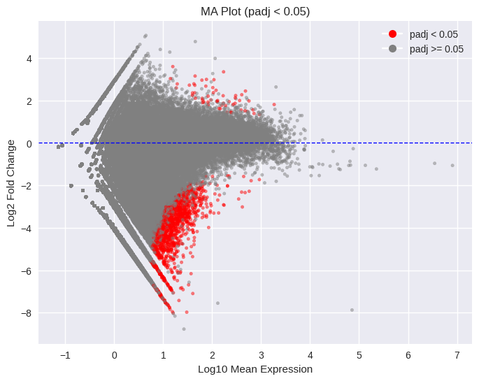

```python
import numpy as np
import matplotlib.pyplot as plt

# MA Plot
plt.figure(figsize=(8, 6))

# Filter out baseMean values that are zero before applying log10
plot_data = results[results['baseMean'] > 0]

# Highlight based on padj < 0.05
sig = plot_data['padj'] < 0.05  # Highlight based on padj < 0.05
colors = ['red' if s else 'gray' for s in sig]

plt.scatter(
    np.log10(plot_data['baseMean']),
    plot_data['log2FoldChange'],
    c=colors,
    alpha=0.5,
    s=10
)

plt.axhline(0, color='blue', linestyle='--', linewidth=1)
plt.xlabel('Log10 Mean Expression')
plt.ylabel('Log2 Fold Change')
plt.title('MA Plot (padj < 0.05)') # Updated title
plt.legend(handles=[
    plt.Line2D([0], [0], marker='o', color='w', markerfacecolor='red', markersize=8, label='padj < 0.05'),
    plt.Line2D([0], [0], marker='o', color='w', markerfacecolor='gray', markersize=8, label='padj >= 0.05') # Updated label
])
plt.show()
```

#### **Interpretation of the MA Plot with padj is less than 0.05**

> **X-axis (Log10 Mean Expression):** This axis shows the average expression level of each gene. Genes to the right are generally more highly expressed.

> **Y-axis (Log2 Fold Change):** This axis indicates the magnitude and direction of gene expression change between the Alzheimer's Disease (AD) and control conditions. Positive values mean upregulation in AD, negative values mean downregulation.

> **Red points:** These represent the genes that are considered statistically significant at the padj < 0.05 threshold. Their position reveals whether they are upregulated or downregulated and by how much.

> **Gray points:** These are genes that did not meet the padj < 0.05 threshold and are not considered statistically significant.

> **Blue dashed line at Y=0:** This line signifies no change in gene expression between the two conditions.

```python
significant_genes_clean = results_clean[results_clean['padj'] < 0.05]
print(f"Number of significant genes in results_clean (padj < 0.05): {len(significant_genes_clean)}")
display(significant_genes_clean.head())
```

```
Number of significant genes in results_clean (padj < 0.05): 1303
```

| Geneid | baseMean | log2FoldChange | lfcSE | stat | pvalue | padj |
| --- | --- | --- | --- | --- | --- | --- |
| ENSG00000238290 | 8.960456 | -6.221513 | 1.810295 | -3.436739 | 0.000589 | 0.019979 |
| ENSG00000235143 | 7.615441 | -5.239390 | 1.577778 | -3.320741 | 0.000898 | 0.026009 |
| ENSG00000233973 | 13.230476 | -4.077229 | 1.260167 | -3.235468 | 0.001214 | 0.031194 |
| ENSG00000132854 | 13.984034 | -4.350812 | 1.243877 | -3.497782 | 0.000469 | 0.017524 |
| ENSG00000284240 | 19.941167 | -4.173584 | 0.965402 | -4.323157 | 0.000015 | 0.002317 |

#### The **Result**: confirms that with the adjusted p-value (padj) threshold set to 0.05, there are **1,303** significant genes.

> The displayed head of the significant_genes_clean DataFrame shows the initial few genes from this filtered list. These genes demonstrate varying log2FoldChange values and baseMean expressions, all with padj values below 0.05.

> This refined list includes genes for which there is stronger statistical evidence of differential expression between the Alzheimer's Disease and control groups, making them highly relevant for further biological investigation.

```python
# Count the number of genes with |log2FoldChange| > 1
count_log2fc_gt_1 = (abs(plot_data['log2FoldChange']) > 1).sum()

print(f"Number of genes with |log2FoldChange| > 1: {count_log2fc_gt_1}")

if count_log2fc_gt_1 > 0:
    print("Yes, red points representing genes with |log2FoldChange| > 1 should now be visible on the MA plot.")
else:
    print("Even with the |log2FoldChange| > 1 threshold, no genes met this criterion. This dataset might not have strong differential expression even in terms of effect size.")
```

```
Number of genes with |log2FoldChange| > 1: 28855
Yes, red points representing genes with |log2FoldChange| > 1 should now be visible on the MA plot.
```

#### **Observations**

> There are **28,855 genes** which show a substantial change in expression, specifically where the absolute log2FoldChange is greater than 1. This means these genes are expressed at least 2-fold higher or 2-fold lower in the Alzheimer's Disease (AD) group compared to the control group.

```python
display(significant_genes_clean)
```

| Geneid | baseMean | log2FoldChange | lfcSE | stat | pvalue | padj |
| --- | --- | --- | --- | --- | --- | --- |
| ENSG00000238290 | 8.960456 | -6.221513 | 1.810295 | -3.436739 | 0.000589 | 0.019979 |
| ENSG00000235143 | 7.615441 | -5.239390 | 1.577778 | -3.320741 | 0.000898 | 0.026009 |
| ENSG00000233973 | 13.230476 | -4.077229 | 1.260167 | -3.235468 | 0.001214 | 0.031194 |
| ENSG00000132854 | 13.984034 | -4.350812 | 1.243877 | -3.497782 | 0.000469 | 0.017524 |
| ENSG00000284240 | 19.941167 | -4.173584 | 0.965402 | -4.323157 | 0.000015 | 0.002317 |
| ... | ... | ... | ... | ... | ... | ... |
| ENSG00000237945 | 141.380200 | -2.456522 | 0.618695 | -3.970487 | 0.000072 | 0.005855 |
| ENSG00000229425 | 27.040113 | -3.574729 | 0.864645 | -4.134332 | 0.000036 | 0.003812 |
| ENSG00000291052 | 26.224946 | -2.346981 | 0.756472 | -3.102536 | 0.001919 | 0.040585 |
| ENSG00000210144 | 92.425799 | -3.209344 | 0.914643 | -3.508849 | 0.000450 | 0.017232 |
| ENSG00000210176 | 22.836571 | -2.908860 | 0.934387 | -3.113122 | 0.001851 | 0.039649 |

1303 rows × 6 columns

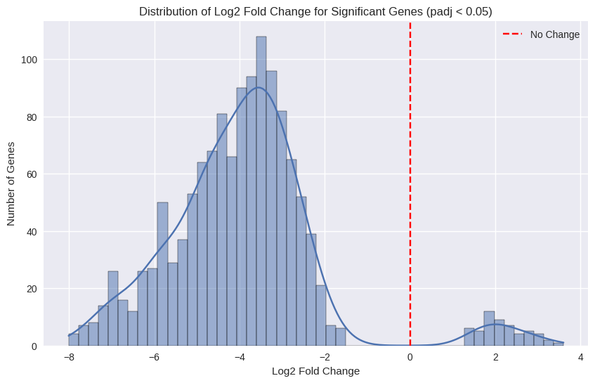

```python
import matplotlib.pyplot as plt
import seaborn as sns

plt.figure(figsize=(10, 6))
sns.histplot(significant_genes_clean['log2FoldChange'], bins=50, kde=True)
plt.title('Distribution of Log2 Fold Change for Significant Genes (padj < 0.05)')
plt.xlabel('Log2 Fold Change')
plt.ylabel('Number of Genes')
plt.axvline(0, color='red', linestyle='--', label='No Change')
plt.legend()
plt.show()
```

#### **Interpretation of the Plot**

The histogram illustrates the distribution of log2FoldChange values specifically for the 1,303 statistically significant genes (those with padj < 0.05).

> Key observations from this distribution are:
> 1. **Strong Downregulation Bias:** The most striking feature is the pronounced skew towards negative log2FoldChange values. This indicates that the majority of significant genes are downregulated in the Alzheimer's Disease (AD) group when compared to the healthy control group. The plot suggests a widespread reduction in gene expression rather than an upregulation.
> 2. **Magnitude of Downregulation:** The density of genes is highest at more negative log2FoldChange values, implying that many significant genes are not just marginally downregulated, but experience substantial decreases in their expression levels.
> 3. **Limited Upregulation:** Conversely, there are very few significant genes with positive log2FoldChange, meaning that significant upregulation in AD is rare in this dataset. Most of the histogram's area lies to the left of the red dashed line at log2FoldChange = 0.

> In summary, this plot strongly suggests that the primary transcriptional response observed in this dataset, for the statistically significant genes, is a suppression of gene activity in the context of Alzheimer's Disease

### **Genes with NaN `padj` values**

```python
nan_padj_genes = results[results['padj'].isna()]
print(f"Number of genes with NaN padj: {len(nan_padj_genes)}")
display(nan_padj_genes.head(10)[['baseMean', 'log2FoldChange', 'pvalue', 'padj']])

print("\nDescriptive statistics for baseMean of NaN padj genes:")
display(nan_padj_genes['baseMean'].describe())
```

```
Number of genes with NaN padj: 39408
```

| Geneid | baseMean | log2FoldChange | pvalue | padj |
| --- | --- | --- | --- | --- |
| ENSG00000279928 | 2.119812 | -0.235588 | 0.913486 | NaN |
| ENSG00000284616 | 0.395131 | -2.964757 | 0.495366 | NaN |
| ENSG00000228463 | 2.886563 | -0.197086 | 0.905592 | NaN |
| ENSG00000260972 | 0.000000 | NaN | NaN | NaN |
| ENSG00000224340 | 0.072306 | -0.192067 | 0.965631 | NaN |
| ENSG00000226374 | 0.658551 | -3.521561 | 0.413512 | NaN |
| ENSG00000229280 | 1.114923 | -4.260507 | 0.222972 | NaN |
| ENSG00000232596 | 2.427523 | -2.730667 | 0.196953 | NaN |
| ENSG00000235054 | 2.626016 | 1.020890 | 0.634103 | NaN |
| ENSG00000231510 | 0.395131 | -2.964757 | 0.495366 | NaN |

```
Descriptive statistics for baseMean of NaN padj genes:
```

|  | baseMean |
| --- | --- |
| count | 39408.000000 |
| mean | 2.922368 |
| std | 361.895635 |
| min | 0.000000 |
| 25% | 0.000000 |
| 50% | 0.395131 |
| 75% | 1.376000 |
| max | 71796.498803 |

**dtype:** float64

#### **Interpretation**

Here's why this occurs and what it means:

> 1. **Internal Filtering:** DESeq2 (and PyDESeq2) performs internal filtering to remove genes that have very low or zero counts across all samples. This is a common and necessary step in RNA-seq analysis.
> 2. **Unreliable Estimation:** For genes with no or very low expression, the model cannot reliably estimate parameters like log2FoldChange or dispersion, as there isn't enough data for a meaningful statistical test.
> 3. **Increased Statistical Power:** Removing these genes helps to increase the statistical power for the remaining genes by reducing the number of multiple comparisons during the adjusted p-value calculation.

## **Volcano Plot**

The Volcano plot combines:

- Effect size (log2FoldChange)
- Statistical significance (-log10 FDR)

Genes in: Upper left → Downregulated Upper right → Upregulated

Common thresholds:

- padj < 0.05
- |log2FC| > 1

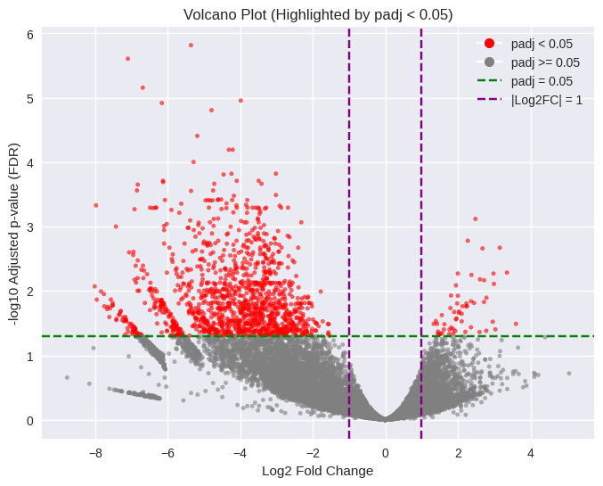

```python
plt.figure(figsize=(8,6))

# Filter out NaNs from relevant columns for plotting
plot_data_volcano = results.dropna(subset=['log2FoldChange', 'padj'])

# Highlight based on padj < 0.05
sig_color = plot_data_volcano['padj'] < 0.05
colors = ['red' if s else 'gray' for s in sig_color]

plt.scatter(plot_data_volcano['log2FoldChange'], -np.log10(plot_data_volcano['padj']), c=colors, alpha=0.6, s=10)

# Add standard threshold lines for reference
plt.axhline(-np.log10(0.05), color='green', linestyle='--', label='padj < 0.05')
plt.axvline(-1, color='purple', linestyle='--', label='Log2FC = -1')
plt.axvline(1, color='purple', linestyle='--', label='Log2FC = 1')

plt.xlabel('Log2 Fold Change')
plt.ylabel('-log10 Adjusted p-value (FDR)')
plt.title('Volcano Plot (Highlighted by padj < 0.05)')

# Create custom legend handles for clarity
legend_handles = [
    plt.Line2D([0], [0], marker='o', color='w', markerfacecolor='red', markersize=8, label='padj < 0.05'),
    plt.Line2D([0], [0], marker='o', color='w', markerfacecolor='gray', markersize=8, label='padj >= 0.05'),
    plt.Line2D([0], [0], color='green', linestyle='--', label='padj = 0.05'),
    plt.Line2D([0], [0], color='purple', linestyle='--', label='|Log2FC| = 1')
]
plt.legend(handles=legend_handles)

plt.show()
```

#### **Interpretation of the Volcano Plot**

> The Volcano plot provides a comprehensive visual summary of the differential expression analysis, combining information about both the effect size (Log2 Fold Change) and statistical significance (adjusted p-value) for every gene.

> The detailed interpretation is as follow:

> **X-axis (Log2 Fold Change):** This axis quantifies the magnitude and direction of gene expression changes between the Alzheimer's Disease (AD) and control conditions. A positive log2FoldChange indicates upregulation in AD, while a negative value indicates downregulation. The further a point is from zero on this axis, the larger the change in expression.

> **Y-axis (-log10 Adjusted p-value (FDR)):** This axis represents the statistical significance of the differential expression. The p-values are adjusted for multiple testing (Benjamini-Hochberg FDR correction) to control the false discovery rate.

> **Green Dashed Horizontal Line (at padj = 0.05):** This line acts as the primary threshold for statistical significance. Any gene plotted above this line has an adjusted p-value (padj) less than 0.05 and is considered statistically significant. Genes below this line are not significant at this threshold.

> **Purple Dashed Vertical Lines (at Log2FC = -1 and Log2FC = 1):** These lines indicate a commonly used threshold for a biologically meaningful fold change. Genes falling outside these lines (to the left of -1 or to the right of 1) represent at least a 2-fold change in expression (up or down). While not strictly a statistical criterion, it helps filter for genes with a substantial biological effect.

> Points on the Plot:

> **Red points:** These are the genes that are considered statistically significant at the padj < 0.05 threshold. Their position reveals both their fold change and their level of significance.

> **Gray points:** These are genes that did not meet the padj < 0.05 threshold and are not considered statistically significant.

> **Key Regions and Their Interpretation:**

> **Upper-Left Quadrant (above green line, left of Y=0, often left of purple -1 line):** Genes in this region are statistically significant and downregulated in AD. These are strong candidates for further investigation as they show both a reliable and substantial decrease in expression.

> **Upper-Right Quadrant (above green line, right of Y=0, often right of purple +1 line):** Genes in this region are statistically significant and upregulated in AD. These are strong candidates for understanding increased gene activity in the disease context.

> From our analysis, the Volcano plot visually confirmed a strong bias towards downregulation, with a dense cluster of significant red points appearing in the upper-left quadrant. The upper-right quadrant, containing significant upregulated genes, appears less densely populated, reinforcing the overall trend of suppressed gene activity in this Alzheimer's Disease dataset.

```python
upregulated_significant_genes = significant_genes_clean[significant_genes_clean['log2FoldChange'] > 0]
display(upregulated_significant_genes)
```

| Geneid | baseMean | log2FoldChange | lfcSE | stat | pvalue | padj |
| --- | --- | --- | --- | --- | --- | --- |
| ENSG00000188641 | 301.881649 | 2.233568 | 0.627510 | 3.559411 | 0.000372 | 0.015598 |
| ENSG00000197622 | 929.498998 | 1.334781 | 0.415604 | 3.211662 | 0.001320 | 0.032469 |
| ENSG00000225313 | 523.217292 | 1.476298 | 0.490848 | 3.007648 | 0.002633 | 0.048321 |
| ENSG00000222112 | 221.632403 | 1.947001 | 0.508148 | 3.831565 | 0.000127 | 0.008189 |
| ENSG00000163162 | 293.968128 | 1.869520 | 0.598615 | 3.123074 | 0.001790 | 0.039142 |
| ENSG00000152128 | 169.115680 | 1.870360 | 0.616320 | 3.034724 | 0.002408 | 0.046029 |
| ENSG00000173744 | 202.938211 | 1.452163 | 0.478550 | 3.034508 | 0.002409 | 0.046029 |
| ENSG00000168906 | 684.255793 | 1.558505 | 0.511956 | 3.044215 | 0.002333 | 0.045048 |
| ENSG00000168890 | 157.435754 | 1.769962 | 0.568129 | 3.115424 | 0.001837 | 0.039604 |
| ENSG00000144724 | 105.784053 | 2.373427 | 0.595392 | 3.986327 | 0.000067 | 0.005634 |
| ENSG00000134851 | 248.791977 | 1.424483 | 0.443200 | 3.214084 | 0.001309 | 0.032399 |
| ENSG00000248810 | 167.524431 | 2.225196 | 0.634285 | 3.508195 | 0.000451 | 0.017232 |
| ENSG00000137462 | 715.407426 | 1.390244 | 0.426112 | 3.262624 | 0.001104 | 0.029318 |
| ENSG00000120708 | 402.459089 | 2.271953 | 0.510183 | 4.453212 | 0.000008 | 0.001659 |
| ENSG00000174705 | 363.617945 | 1.999145 | 0.543989 | 3.674970 | 0.000238 | 0.011866 |
| ENSG00000274441 | 388.836435 | 1.556406 | 0.463450 | 3.358308 | 0.000784 | 0.023746 |
| ENSG00000112893 | 478.710821 | 2.447410 | 0.685872 | 3.568320 | 0.000359 | 0.015356 |
| ENSG00000256235 | 34.232317 | 2.722926 | 0.694716 | 3.919478 | 0.000089 | 0.006815 |
| ENSG00000124491 | 108.691218 | 2.980178 | 0.744408 | 4.003420 | 0.000062 | 0.005359 |
| ENSG00000274272 | 188.302868 | 1.761158 | 0.581735 | 3.027422 | 0.002466 | 0.046693 |
| ENSG00000106565 | 62.737041 | 2.103792 | 0.622268 | 3.380845 | 0.000723 | 0.022554 |
| ENSG00000147454 | 1844.637109 | 1.811092 | 0.492186 | 3.679693 | 0.000234 | 0.011773 |
| ENSG00000250031 | 74.215990 | 2.678234 | 0.616855 | 4.341757 | 0.000014 | 0.002185 |
| ENSG00000164761 | 42.406184 | 2.785636 | 0.764337 | 3.644512 | 0.000268 | 0.012756 |
| ENSG00000178719 | 469.337055 | 1.520855 | 0.502675 | 3.025521 | 0.002482 | 0.046733 |
| ENSG00000119431 | 14.049374 | 3.032487 | 0.972652 | 3.117750 | 0.001822 | 0.039467 |
| ENSG00000262655 | 44.280879 | 2.717879 | 0.758301 | 3.584170 | 0.000338 | 0.014831 |
| ENSG00000120457 | 102.961534 | 2.608607 | 0.663034 | 3.934346 | 0.000083 | 0.006591 |
| ENSG00000185475 | 83.389177 | 1.793825 | 0.516338 | 3.474127 | 0.000513 | 0.018428 |
| ENSG00000232875 | 19.348035 | 2.780938 | 0.899646 | 3.091148 | 0.001994 | 0.041487 |
| ENSG00000152766 | 44.782011 | 3.153506 | 0.724384 | 4.353365 | 0.000013 | 0.002129 |
| ENSG00000107957 | 146.976148 | 1.613298 | 0.517787 | 3.115756 | 0.001835 | 0.039604 |
| ENSG00000269609 | 63.072203 | 2.029123 | 0.593195 | 3.420671 | 0.000625 | 0.020745 |
| ENSG00000136040 | 120.141559 | 2.482523 | 0.524729 | 4.731057 | 0.000002 | 0.000761 |
| ENSG00000255150 | 18.523436 | 2.594257 | 0.846628 | 3.064222 | 0.002182 | 0.043472 |
| ENSG00000135677 | 242.924687 | 1.451254 | 0.472014 | 3.074598 | 0.002108 | 0.042717 |
| ENSG00000256399 | 94.103337 | 2.026753 | 0.596820 | 3.395919 | 0.000684 | 0.021874 |
| ENSG00000213906 | 66.900753 | 1.945020 | 0.590380 | 3.294521 | 0.000986 | 0.027598 |
| ENSG00000156381 | 76.420739 | 2.993531 | 0.776098 | 3.857158 | 0.000115 | 0.007763 |
| ENSG00000167208 | 64.427344 | 1.898552 | 0.556828 | 3.409585 | 0.000651 | 0.021214 |
| ENSG00000169955 | 44.142631 | 2.363364 | 0.657336 | 3.595369 | 0.000324 | 0.014460 |
| ENSG00000167207 | 82.707206 | 2.205475 | 0.718854 | 3.068043 | 0.002155 | 0.043151 |
| ENSG00000287431 | 15.706691 | 3.600193 | 1.119326 | 3.216392 | 0.001298 | 0.032399 |
| ENSG00000290793 | 61.773232 | 2.959592 | 0.909805 | 3.252995 | 0.001142 | 0.030057 |
| ENSG00000196209 | 565.443606 | 1.980015 | 0.556897 | 3.555441 | 0.000377 | 0.015620 |
| ENSG00000178726 | 171.151939 | 3.351537 | 0.833449 | 4.021285 | 0.000058 | 0.005177 |
| ENSG00000197405 | 296.271671 | 2.125195 | 0.606178 | 3.505895 | 0.000455 | 0.017275 |
| ENSG00000187474 | 39.760381 | 2.358413 | 0.747549 | 3.154861 | 0.001606 | 0.036681 |
| ENSG00000130202 | 126.055753 | 1.961211 | 0.592455 | 3.310312 | 0.000932 | 0.026630 |
| ENSG00000130203 | 268.483217 | 1.817362 | 0.576586 | 3.151934 | 0.001622 | 0.036894 |
| ENSG00000179820 | 129.444869 | 1.998173 | 0.499079 | 4.003723 | 0.000062 | 0.005359 |
| ENSG00000168995 | 82.000761 | 1.927458 | 0.624272 | 3.087527 | 0.002018 | 0.041698 |
| ENSG00000160117 | 39.379638 | 2.251240 | 0.641376 | 3.510013 | 0.000448 | 0.017232 |
| ENSG00000099977 | 45.459777 | 2.105063 | 0.645986 | 3.258683 | 0.001119 | 0.029627 |
| ENSG00000100219 | 138.848534 | 1.627838 | 0.507781 | 3.205790 | 0.001347 | 0.032823 |

#### **Key Observations from the Upregulated Significant Genes**

> Genes that are located in the upper-right quadrant of the volcano plot. This means that these genes are both statistically significant (padj < 0.05) and show increased expression (log2FoldChange > 0) in the Alzheimer's Disease (AD) group compared to controls.

> Thus, list identifies a crucial set of genes that are consistently and significantly expressed at higher levels in the AD samples. These genes are strong candidates for contributing to AD pathology or serving as biomarkers, and warrant further biological investigation to understand their functional roles.

```python
downregulated_significant_genes = significant_genes_clean[significant_genes_clean['log2FoldChange'] < 0]
display(downregulated_significant_genes)
```

| Geneid | baseMean | log2FoldChange | lfcSE | stat | pvalue | padj |
| --- | --- | --- | --- | --- | --- | --- |
| ENSG00000238290 | 8.960456 | -6.221513 | 1.810295 | -3.436739 | 0.000589 | 0.019979 |
| ENSG00000235143 | 7.615441 | -5.239390 | 1.577778 | -3.320741 | 0.000898 | 0.026009 |
| ENSG00000233973 | 13.230476 | -4.077229 | 1.260167 | -3.235468 | 0.001214 | 0.031194 |
| ENSG00000132854 | 13.984034 | -4.350812 | 1.243877 | -3.497782 | 0.000469 | 0.017524 |
| ENSG00000284240 | 19.941167 | -4.173584 | 0.965402 | -4.323157 | 0.000015 | 0.002317 |
| ... | ... | ... | ... | ... | ... | ... |
| ENSG00000237945 | 141.380200 | -2.456522 | 0.618695 | -3.970487 | 0.000072 | 0.005855 |
| ENSG00000229425 | 27.040113 | -3.574729 | 0.864645 | -4.134332 | 0.000036 | 0.003812 |
| ENSG00000291052 | 26.224946 | -2.346981 | 0.756472 | -3.102536 | 0.001919 | 0.040585 |
| ENSG00000210144 | 92.425799 | -3.209344 | 0.914643 | -3.508849 | 0.000450 | 0.017232 |
| ENSG00000210176 | 22.836571 | -2.908860 | 0.934387 | -3.113122 | 0.001851 | 0.039649 |

1248 rows × 6 columns

```python
from google.colab import drive
drive.mount('/content/drive')
```

#### **Key Observations from the Downregulated Significant Genes**

> The list of 1,248 genes that are both statistically significant (padj < 0.05) and show decreased expression (log2FoldChange < 0) in the Alzheimer's Disease (AD) group compared to controls. This corresponds to the genes in the upper-left quadrant of the volcano plot.

Key observations include:

> 1. **Downregulation:** All genes in this list have a negative log2FoldChange, indicating they are downregulated in AD. The log2FoldChange values range from approximately -1.55 to -8.01, signifying substantial decreases in expression (e.g., a log2FoldChange of -8.01 means an approximate 2^8.01 ≈ 257-fold decrease).
> 2. **Statistical Significance:** The padj values are all below 0.05, with many being very low, reinforcing the strong statistical confidence in these observed changes.
> 3. **baseMean:** These genes also display varying average expression levels (baseMean), similar to the upregulated genes.

> This list highlights a significant set of genes that are consistently and significantly expressed at lower levels in the AD samples. These genes are strong candidates for contributing to AD pathology, as their reduced activity might play a role in disease progression, and they warrant further biological investigation

## **Conclusion**

> Our PyDESeq2 analysis of gene expression profiles between Alzheimer's Disease (AD) and healthy control samples, based on the provided gene count matrix from Myeloid, successfully identified 1,303 statistically significant differentially expressed genes (adjusted p-value, padj < 0.05).

> This finding is robustly supported by:
> 1. **Clear Statistical Significance:** A substantial number of genes passed the padj < 0.05 threshold, indicating strong evidence of differential expression.
> 2. **Predominant Downregulation:** The MA plot, the histogram of log2FoldChange for significant genes, and the Volcano plot all consistently show a striking bias towards downregulation in the AD samples compared to controls. The majority of significant genes exhibit negative log2FoldChange values, with many showing very large magnitudes of decrease in expression.
> 3. **Upregulated Genes Present:** While less numerous, a distinct set of significant upregulated genes were also identified in the upper-right quadrant of the Volcano plot, offering specific targets for investigation into AD-associated increases in gene activity.

## **Key Insights from The Study's Findings**

> **Significant Transcriptional Changes in AD:** The identification of 1,303 differentially expressed genes highlights a considerable impact of Alzheimer's Disease on gene regulation in the myeloid cell type studied, suggesting substantial molecular reprogramming.

> **Major Downregulation Signature:** The strong prevalence of downregulated genes points towards processes that might be suppressed or diminished in AD. This could involve reduced metabolic activity, impaired immune responses, or altered cellular functions that contribute to disease pathology.

> **Specific Candidate Genes Identified:** Both highly downregulated and a smaller set of highly upregulated genes have been identified, providing concrete molecular targets for further investigation into their roles in AD etiology and progression.